# Potential Forest Harvest Volume Impact Summary for 2020/21 Priority Caribou Herd Planning Areas

Tyler Muhly, Kyle Lochhead and Elizabeth Kleynhans

19/08/2020

## Introduction

Caribou population recovery will require recovery of caribou habitat in many parts of British Columbia. This might include additional, new constraints on forestry activity in some areas to reduce the amount of ‘disturbance’ in caribou critical habitat. Disturbances include forestry cutblocks and roads that generally appear to negatively influence caribou survival.

Here we describe a preliminary analysis of the potential impacts of new hypothetical constraints on forest harvest in caribou critical habitat areas. We used a spatial timber harvest/supply model to test how new hypothetical constraints on forest harvest in caribou critical habitat areas influence annual timber volume harvested (m<sup>3</sup>) in a harvest unit. We compared forest harvest in hypothetical scenarios to a ‘business-as-usual’ (BAU) scenario. The BAU scenario applied existing, legal forest harvest constraints, as is typically done in timber supply reviews. The alternative scenarios (i.e., with new hypothetical constraints) to the BAU included:

- no forest harvest in caribou critical habitat areas (as defined by government of British Columbia caribou biologists)
- no forest harvest in high and low elevation critical habitat types, but maximum 35% disturbance area in matrix critical habitat
- no forest harvest in caribou herd boundary areas, where critical habitat areas have not been defined
- no forest harvest in other areas identified for caribou (i.e., areas as defined in the southern mountain caribou Section 11 Partnership Agreement)

Analyses were focussed on timber supply areas (TSAs) or tree farm licence (TFL) areas that overlapped with caribou planning priority areas in 2020/21, which included:

- Central Selkirks
- Chilcotin
- Hart Ranges
- Revelstoke (Columbia North/Columbia South/Frisby Boulder)
- Wolverine/Chase/Takla
- Wells Grey South/Groundhog

In addition, scenarios were completed to assess the potential impact of protecting all caribou critical habitat in a TSA or TFL, regardless of whether the habitat was within a priority area. These can be viewed as “maximum” potential impact scenarios, where forest harvest constraints are applied to all caribou critical habitat in a harvest unit.

The results of these analyses should be considered preliminary and subject to change. The parameters in the timber harvest/supply models used in this analysis were standardized across forest harvest units, but model outputs may be different if the models are parameterized differently to better fit local conditions. The annual timber volume estimates from these models should therefore be used with caution, as they may have a low degree of precision.

We also note that our BAU scenarios were not equivalent to the ‘base-case’ models used in previous timber supply reviews for a TSA or TFL, and thus are not directly comparable. Of key importance is that we modeled an even, maximum sustained harvest flow over a 200 year period in our BAU models, which is not typically the approach taken in timber supply reviews. However, our approach is reasonable for assessing potential long-term impacts to timber supply.

## Potential Annual Timber Volume Harvested Under Different Scenarios by Timber Supply Area or Tree Farm Licence

Potential timber volume harvested under different scenarios for each forest harvest unit are provided in Table 1. Potential impacts of the hypothetical forest harvest scenarios compared to BAU scenarios varied significantly between harvest units, from a <1% reduction from BAU for some scenarios in the Prince George TSA, to a 100% reduction from BAU for scenarios for TFL 30. Some of the largest potential impacts compared to BAU were found in the Revelstoke TSA and TFL’s 30, 33, 48 and 55.

**Table 1. Annual Harvested Timber Volume Over a 200 Year Period in Timber Harvest Units Under Different Caribou Recovery Scenarios.**

| Harvest Unit | Scenario | Average Annual Volume (m3) | Difference in Annual Volume (m3) | Percent Difference in Annual Volume |
| --- | --- | --- | --- | --- |
| Arrow TSA | BAU | 344,356 | 0 | 0 |
| Arrow TSA | No harvest in Central Selkirks critical habitat | 329,267 | -15,089 | -4% |
| Arrow TSA | 35% disturbance in Central Selkirks matrix critical habitat | 331,990 | -12,366 | -4% |
| Arrow TSA | No harvest in all critical habitat | 296,705 | -47,651 | -14% |
| Arrow TSA | 35% disturbance in all matrix critical habitat | 306,363 | -37,993 | -11% |
| Cascadia TSA - Kootenay Block | BAU | 82,463 | 0 | 0 |
| Cascadia TSA - Kootenay Block | No harvest in Central Selkirks critical habitat | 75,452 | -7,011 | -9% |
| Cascadia TSA - Kootenay Block | 35% disturbance in Central Selkirks matrix critical habitat | 75,451 | -7,012 | -9% |
| Dawson Creek TSA | BAU | 1,409,979 | 0 | 0 |
| Dawson Creek TSA | No harvest in Central Group critical habitat | 721,306 | -688,673 | -49% |
| Dawson Creek TSA | 35% disturbance in Central Group matrix critical habitat | 841,712 | -568,267 | -40% |
| Dawson Creek TSA | No harvest in Central group partnership agreement areas A2, B2, and B3, maximum 35% disturbance (15%) harvest in Central group partnership agreement areas A1, B1, B4 and B5 | 1,304,409 | -105,570 | -7% |
| Dawson Creek TSA | No harvest in all Central group partnership agreement areas | 1,293,152 | -116,827 | -8% |
| Dawson Creek TSA | No harvest in all critical habitat | 704,697 | -705,282 | -50% |
| Dawson Creek TSA | 35% disturbance in all matrix critical habitat | 827,524 | -582,455 | -41% |
| Golden TSA | BAU | 382,453 | 0 | 0 |
| Golden TSA | No harvest in Central Selkirks critical habitat | 362,213 | -20,240 | -5% |
| Golden TSA | 35% disturbance in Central Selkirks matrix critical habitat | 368,439 | -14,014 | -4% |
| Golden TSA | No harvest in Columbia North and South | 344,500 | -37,953 | -10% |
| Golden TSA | 35% disturbance in Columbia North and South matrix critical habitat | 357,945 | -24,508 | -6% |
| Golden TSA | No harvest in all critical habitat | 251,325 | -131,128 | -34% |
| Golden TSA | 35% disturbance in all matrix critical habitat | 308,320 | -74,133 | -19% |
| Great Bear Rainforest North | BAU | 419,931 | 0 | 0 |
| Great Bear Rainforest North | No harvest in Chilcotin critical habitat | 419,931 | 0 | 0 |
| Great Bear Rainforest North | 35% disturbance in Chilcotin matrix critical habitat | 419,931 | 0 | 0 |
| Great Bear Rainforest South | BAU | 619,914 | 0 | 0 |
| Great Bear Rainforest South | No harvest in Chilcotin critical habitat | 619,914 | 0 | 0 |
| Great Bear Rainforest South | 35% disturbance in Chilcotin matrix critical habitat | 619,914 | 0 | 0 |
| Kamloops TSA | BAU | 1,149,967 | 0 | 0 |
| Kamloops TSA | No harvest in Columbia North, Columbia South and Frisby-Boulder critical habitat | 1,122,900 | -27,067 | -2% |

[output cut: 105 more lines]

Note:  
BAU = business-as-usual scenario

In the Central Group planning area, the no harvest in critical habitat scenario had the highest relative potential timber volume impact in TFL 48, and lowest relative potential impact in the Prince George TSA (Fig. 1).

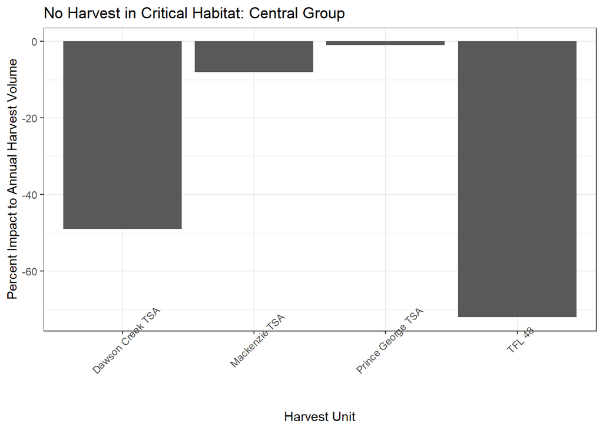

Figure 1. Percent Timber Harvest Volume Impacts by Harvest Unit in the Central Group Planning Area.

In the Central Selkirks planning area, the no harvest in critical habitat scenario had the highest relative potential timber volume impact in TFL 14, and lowest relative impact in the Arrow TSA (Fig. 2).

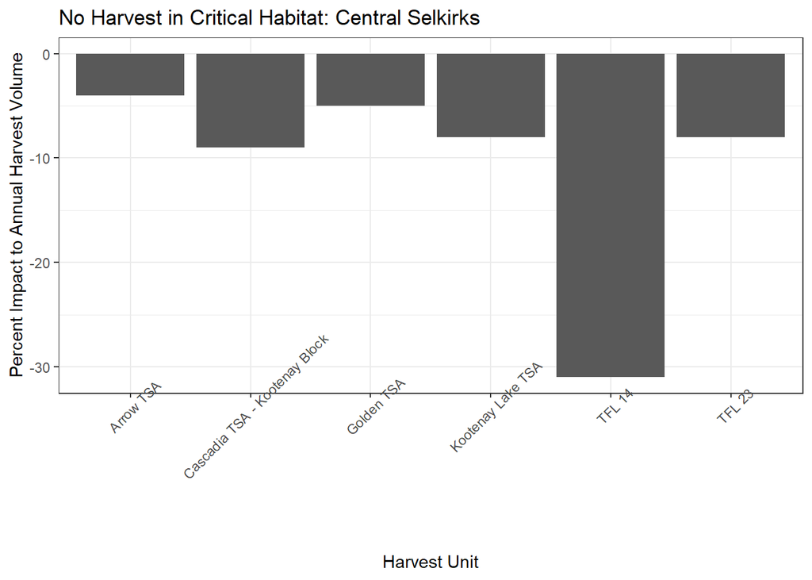

Figure 2. Percent Timber Harvest Volume Impacts by Harvest Unit in the Central Selkirks Planning Area.

In the Chilcotin planning area, the no harvest in critical habitat scenario had the highest relative potential timber volume impact in the Lakes TSA, and lowest relative potential impact in the Prince George TSA (Fig. 3). There was no impact in either of the Great Bear Rainforest TSAs.

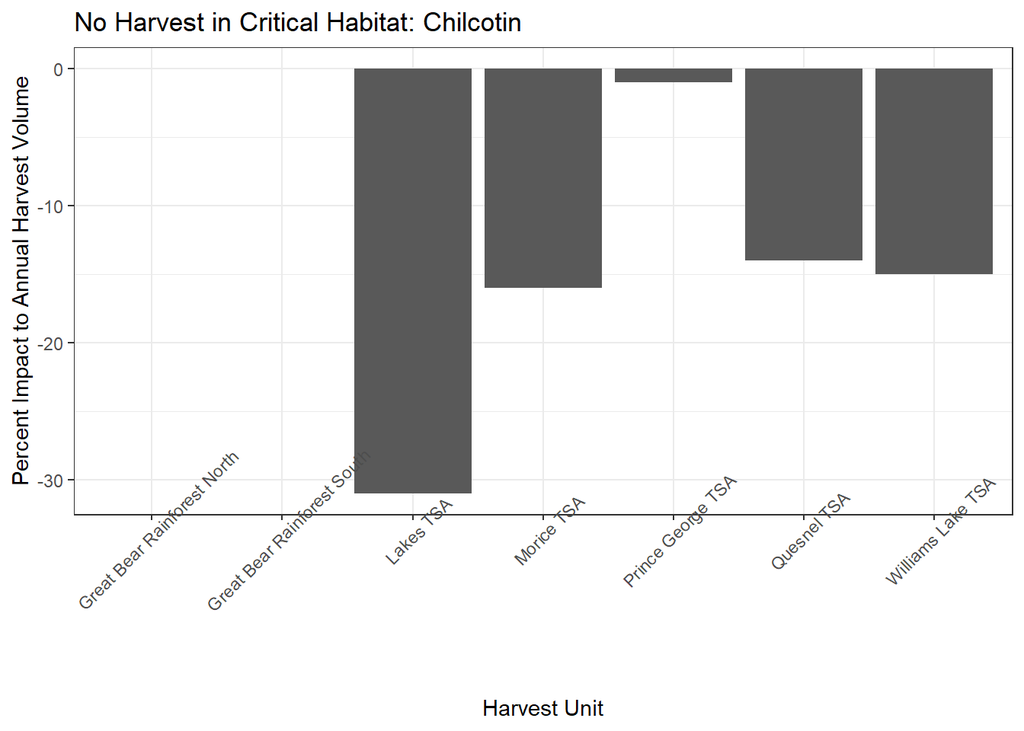

Figure 3. Percent Timber Harvest Volume Impacts by Harvest Unit in the Chilcotin Planning Area.

In the Revelstoke planning area, the no harvest in critical habitat scenario had the highest relative potential timber volume impact in TFL 33, TFL 56 and the Revelstoke TSA, and lowest relative potential impact in TFL 23 and the Robson Valley TSA (Fig. 4).

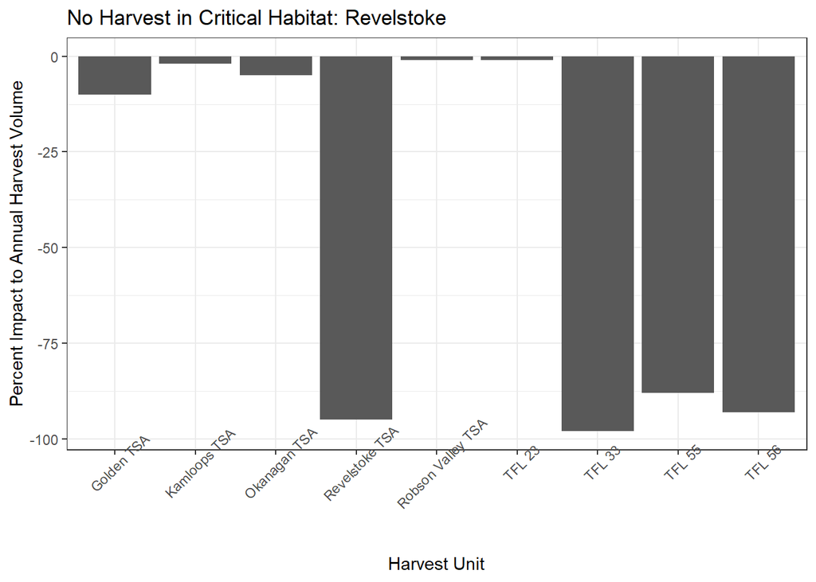

Figure 4. Percent Timber Harvest Volume Impacts by Harvest Unit in the Revelstoke Planning Area.

In the Hart Ranges planning area, the no harvest in critical habitat scenario had the highest relative potential timber volume impact in TFL 30, and lowest relative potential impact in the Prince George TSA (Fig. 5).

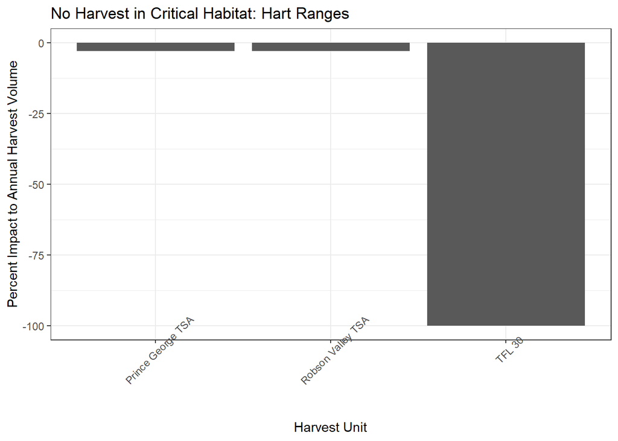

Figure 5. Percent Timber Harvest Volume Impacts by Harvest Unit in the Hart Ranges Planning Area.

In the Wells Gray South/Groundhog planning area, the no harvest in critical habitat scenario had the highest relative potential timber volume impact in TFL 18, and lowest relative potential impact in the Robson Valley TSA (Fig. 6).

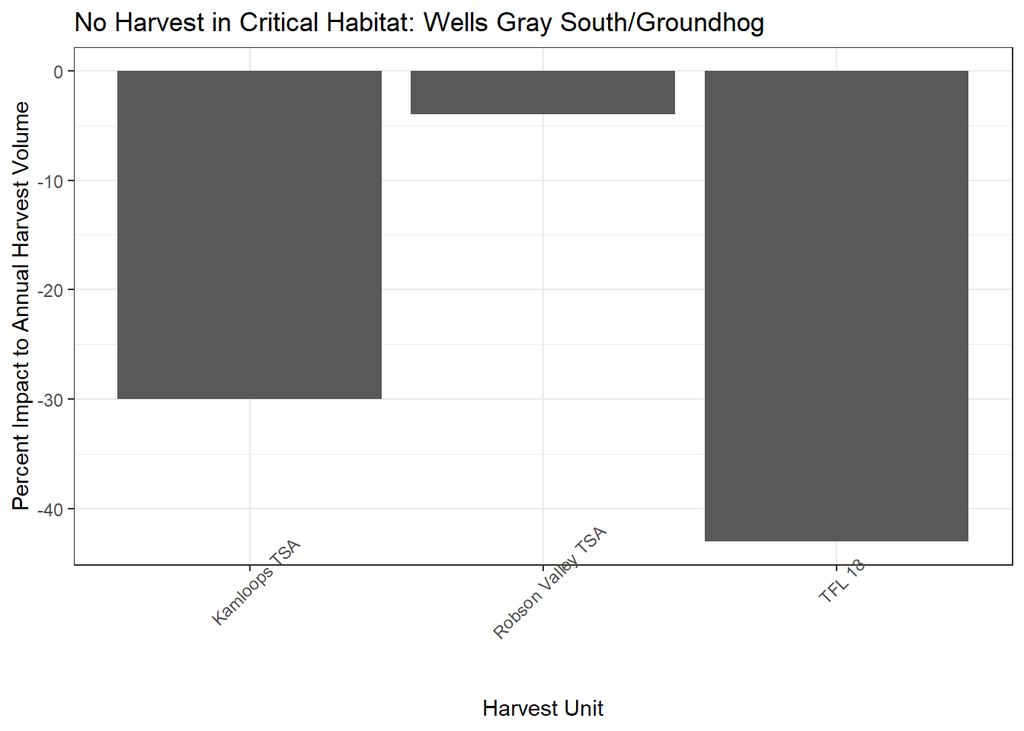

Figure 6. Percent Timber Harvest Volume Impacts by Harvest Unit in the Wells Gray South/Groundhog Planning Area.

In the Wolverine/Chase/Takla planning area, the no harvest in herd boundaries scenario had the highest relative potential timber volume impact in the Mackenzie TSA, and lowest relative potential impact in the Lakes TSA (Fig. 7).

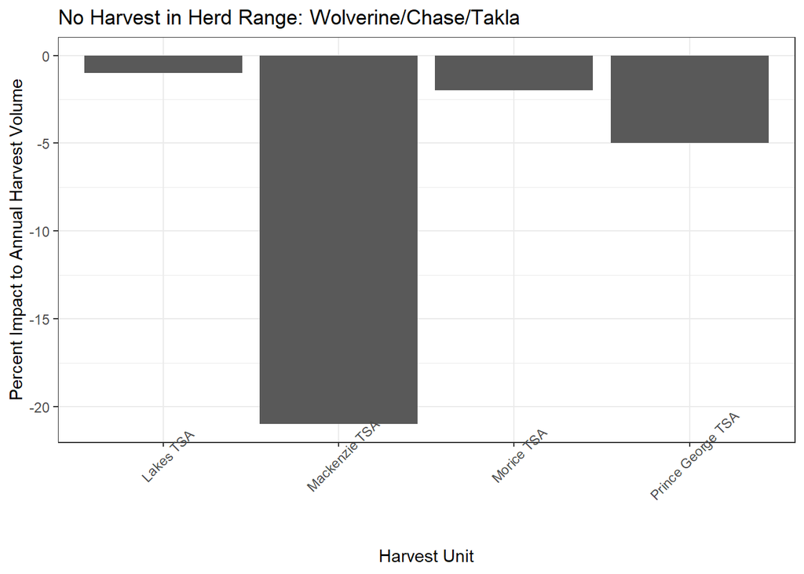

Figure 7. Percent Timber Harvest Volume Impacts by Harvest Unit in the Wolverine/Chase/Takla Planning Area.

## Potential Annual Timber Volume Harvested Under Different Scenarios by Priority Caribou Herd Planning Area

The potential timber volume harvested under different scenarios for each priority caribou planning area are provided in Table 2. In terms of potential impact to total harvest volume, the largest potential impacts occurred in the Central Group, Chilcotin and Wolverine/Chase/Takla planning areas, i.e., -1,126,188m<sup>3</sup>, -938,896m<sup>3</sup> and -828,938m<sup>3</sup>, respectively, for scenarios with no harvest compared to BAU. In terms of the potential percentage impact to harvest volume, the largest potential impacts occurred in the Wells Gray South/Groundhog, Central Group and Revelstoke planning areas, 27%, 11% and 10%, respectively, for scenarios with no harvest compared to BAU.

**Table 2. Annual Harvested Timber Volume Over a 200 Year Period by Caribou Planning Area Under Different Caribou Recovery Scenarios.**

| Caribou Planning Area | Scenario | Average Annual Volume (m3) | Difference in Annual Volume (m3) | Percent Difference in Annual Volume |
| --- | --- | --- | --- | --- |
| Central Group | BAU | 10,658,593 | 0 | 0 |
| Central Group | No harvest in critical habitat | 9,532,405 | -1,126,188 | -11% |
| Central Group | 35% disturbance in matrix critical habitat | 9,767,734 | -890,859 | -8% |
| Central Selkirks | BAU | 1,790,139 | 0 | 0 |
| Central Selkirks | No harvest in critical habitat | 1,640,825 | -149,314 | -8% |
| Central Selkirks | 35% disturbance in matrix critical habitat | 1,706,092 | -84,047 | -5% |
| Chilcotin | BAU | 13,299,188 | 0 | 0 |
| Chilcotin | No harvest in critical habitat | 12,360,292 | -938,896 | -7% |
| Chilcotin | 35% disturbance in matrix critical habitat | 12,565,535 | -733,653 | -6% |
| Hart Ranges | BAU | 7,052,780 | 0 | 0 |
| Hart Ranges | No harvest in critical habitat | 6,708,338 | -344,442 | -5% |
| Hart Ranges | 35% disturbance in matrix critical habitat | 6,728,186 | -324,594 | -5% |
| Partenership Agreement | BAU | 10,658,593 | 0 | 0 |
| Partenership Agreement | No harvest in all Partnership Agreement Areas | 10,437,691 | -220,902 | -2% |
| Partenership Agreement | No harvest in Central group partnership agreement areas A2, B2, and B3, maximum 35% buffered disturbance in Central group partnership agreement areas A1, B1, B4 and B5 | 10,464,906 | -193,687 | -2% |
| Revelstoke | BAU | 3,504,325 | 0 | 0 |
| Revelstoke | No harvest in critical habitat | 3,166,017 | -338,308 | -10% |
| Revelstoke | 35% disturbance in matrix critical habitat | 3,252,520 | -251,805 | -7% |
| Wells Gray South/Groundhog | BAU | 1,459,268 | 0 | 0 |
| Wells Gray South/Groundhog | No harvest in critical habitat | 1,059,871 | -399,397 | -27% |
| Wells Gray South/Groundhog | 35% disturbance in matrix critical habitat | 1,136,336 | -322,932 | -22% |
| Wolverine/Chase/Takla | BAU | 10,894,709 | 0 | 0 |
| Wolverine/Chase/Takla | No harvest in herd boundaries | 10,065,771 | -828,938 | -8% |

Note:  
BAU = business-as-usual scenario

## Conclusions

Here we provide results of a preliminary analysis of the potential impacts to timber supply of reducing forest harvest in caribou critical habitat or herd ranges. The results likely indicate closer to the maximum potential impacts to timber supply. This may be a useful starting point for caribou recovery planning, as forest harvest constraints could be refined within specific planning areas, and potential impacts of constraints on timber supply may be reduced through this refinement.

We note that potential impacts to forestry vary depending on whether impacts are assessed within a caribou planning unit area or forest harvest unit (TSA or TFL). For example, maximum potential impacts in the Revelstoke caribou planning unit reached a 10%, or 338,308m<sup>3</sup> reduction in timber supply compared to BAU, but they disproportionately impacted the Revelstoke TSA, which had a 95%, or 147,300m<sup>3</sup> reduction in timber supply compared to BAU. Thus, it’s important to consider timber supply impacts at different scales.

We compared our annual harvested volume results to results from timber supply analyses completed for previous TSA and TFL timber supply reviews. In general, our results were consistent with the results of analyses completed for TSAs. However, we consistently estimated much lower levels of timber supply in TFLs compared to estimates from models used for TFL timber supply reviews. This may be due to some fundamental differences in how we modeled timber harvest (e.g., use of optimization versus spatial timber supply models, or differences in how forest stands were prioritized for harvest). However, we did note problems with the forest inventory data we had for some of the TFLs. In particular, many stands in TFL 33 did not have site index values, meaning we were unable to estimate future stand volumes for most of the area. In addition, it was noted in the last timber supply review for TFL 48 that the forest inventory consistently underestimated volume, and thus they developed a model to adjust the volume of forest stands. We did not have access to that model, and therefore our estimates were made without this adjustment, resulting in lower timber supply estimates. Results for several of the TFL areas appeared to be unreliable and should be used with extra caution.